# Reproducible Research: Peer Assessment 1

## Loading and preprocessing the data

1. Load the data

```r
    fitdata <- read.csv("./activity.csv")
```

2. Process/transform the data into a format suitable for analysis

Here I will convert the class of the ‘date’ column from factor to character. This will make it easier to work with.

```r
    fitdata$date <- as.character(fitdata$date)
```

## What is mean total number of steps taken per day?

1. Calculate the total number of steps taken per day

```r
    as.data.frame.table(tapply(fitdata$steps, fitdata$date, sum, na.rm=TRUE))
```

```
##          Var1  Freq
## 1  2012-10-01     0
## 2  2012-10-02   126
## 3  2012-10-03 11352
## 4  2012-10-04 12116
## 5  2012-10-05 13294
## 6  2012-10-06 15420
## 7  2012-10-07 11015
## 8  2012-10-08     0
## 9  2012-10-09 12811
## 10 2012-10-10  9900
## 11 2012-10-11 10304
## 12 2012-10-12 17382
## 13 2012-10-13 12426
## 14 2012-10-14 15098
```

[output cut: 47 more lines]

2. Make a histogram of the total number of steps taken each day

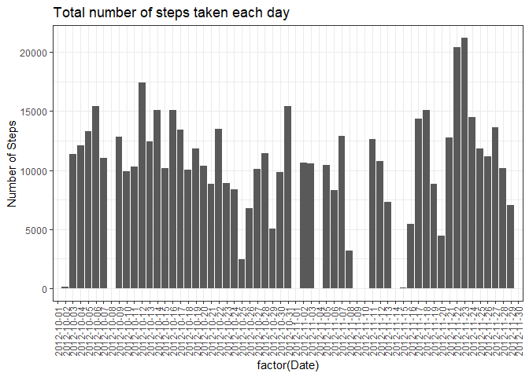

```r
    steps_date <- tapply(fitdata$steps, fitdata$date, sum, na.rm=TRUE)
    steps_date <- as.data.frame.table(steps_date)
    names(steps_date) <- c("Date", "Steps")

    library(ggplot2)
    ggp <- ggplot(steps_date, aes(factor(Date), Steps)) +
        geom_bar(stat="identity") +
        theme_bw() + guides(fill=FALSE) +
        theme(axis.text.x = element_text(angle = 90, vjust = 0.5, hjust=1)) +
        labs(y="Number of Steps", title="Total number of steps taken each day")

    print(ggp)
```

3. Calculate and report the mean and median of the total number of steps taken per day

```r
    fitdata2 <- read.csv("./activity.csv", colClasses = c("numeric", "character", "numeric"), na.strings=c("NA", "0"))
    ## Next I want to replace the NA that is taking up the 0 entry in the interval column. I had to change the behavior of the dataframe to treat 0's as NA because if I didn't the median of all dates would = 0, and the instructions say to ignore missing values.
    mean_steps <- as.data.frame.table(tapply(fitdata2$steps, fitdata2$date, mean, na.rm=TRUE))
    median_steps <- as.data.frame.table(tapply(fitdata2$steps, fitdata2$date, median, na.rm=TRUE))

    print(mean_steps)
```

```
##          Var1      Freq
## 1  2012-10-01       NaN
## 2  2012-10-02  63.00000
## 3  2012-10-03 140.14815
## 4  2012-10-04 121.16000
## 5  2012-10-05 154.58140
## 6  2012-10-06 145.47170
## 7  2012-10-07 101.99074
## 8  2012-10-08       NaN
## 9  2012-10-09 134.85263
## 10 2012-10-10  95.19231
## 11 2012-10-11 137.38667
## 12 2012-10-12 156.59459
## 13 2012-10-13 119.48077
## 14 2012-10-14 160.61702
```

[output cut: 47 more lines]

```r
    print(median_steps)
```

```
##          Var1  Freq
## 1  2012-10-01    NA
## 2  2012-10-02  63.0
## 3  2012-10-03  61.0
## 4  2012-10-04  56.5
## 5  2012-10-05  66.0
## 6  2012-10-06  67.0
## 7  2012-10-07  52.5
## 8  2012-10-08    NA
## 9  2012-10-09  48.0
## 10 2012-10-10  56.5
## 11 2012-10-11  35.0
## 12 2012-10-12  46.0
## 13 2012-10-13  45.5
## 14 2012-10-14  60.5
```

[output cut: 47 more lines]

## What is the average daily activity pattern?

1. Make a time series plot (i.e. type = “l”) of the 5-minute interval (x-axis) and the average number of steps taken, averaged across all days (y-axis)

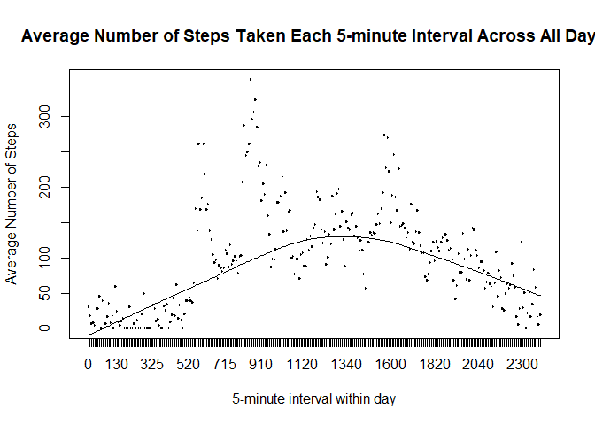

```r
    ## The 0th interval was replaced with an NA value by the last read.csv call, so here I change those row's intervals back to 0
    fitdata2$interval[is.na(fitdata2$interval)] <- 0
    steps_interval <- tapply(fitdata2$steps, fitdata2$interval, mean, na.rm=TRUE)
    steps_interval <- as.data.frame.table(steps_interval)
    names(steps_interval) <- c("Interval", "Steps")

    steps_interval$Interval[is.na(steps_interval$Interval)] <- 0
    steps_interval$Steps[is.na(steps_interval$Steps)] <- 0

    with(steps_interval, plot(Interval, Steps, type="l", main="Average Number of Steps Taken Each 5-minute Interval Across All Days", xlab="5-minute interval within day", ylab="Average Number of Steps"))
    with(steps_interval, lines(stats::lowess(steps_interval)))
```

2. Which 5-minute interval, on average across all the days in the dataset, contains the maximum number of steps?

```r
    max_index <- which.max(steps_interval$Steps)

    steps_interval$Interval[max_index]
```

```
## [1] 835
## 288 Levels: 0 5 10 15 20 25 30 35 40 45 50 55 100 105 110 115 120 125 ... 2355
```

## Imputing missing values

1. Calculate and report the total number of missing values in the dataset (i.e. the total number of rows with NAs)

```r
    fitdata3 <- read.csv("./activity.csv")
    sum(is.na(fitdata3))
```

```
## [1] 2304
```

2. Devise a strategy for filling in all of the missing values in the dataset. The strategy does not need to be sophisticated. For example, you could use the mean/median for that day, or the mean for that 5-minute interval, etc.

```
Replace each NA value with the mean for that 5-minute interval
```

3. Create a new dataset that is equal to the original dataset but with the missing data filled in.

```r
    fitdata_imputed <- fitdata3
    for (i in 1:nrow(fitdata_imputed)) {
      if (is.na(fitdata_imputed$steps[i])) {
        interval_value <- fitdata_imputed$interval[i]
        steps_value <- steps_interval[steps_interval$Interval == interval_value,]
        fitdata_imputed$steps[i] <- steps_value$Steps
      }
    }
```

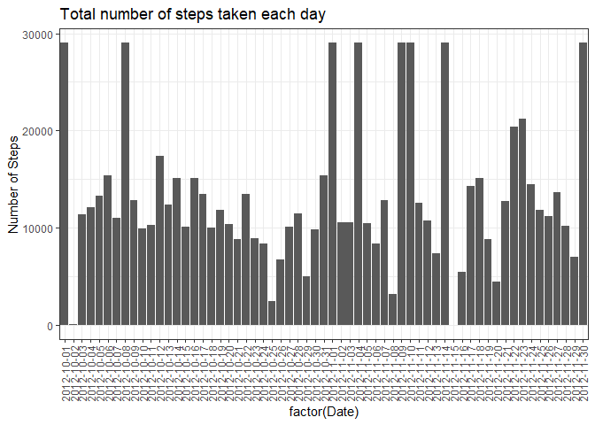

```r
    ## Histogram
    steps_date_complete <- tapply(fitdata_imputed$steps, fitdata_imputed$date, sum, na.rm=TRUE)
    steps_date_complete <- as.data.frame.table(steps_date_complete)
    names(steps_date_complete) <- c("Date", "Steps")

    library(ggplot2)
    ggp <- ggplot(steps_date_complete, aes(factor(Date), Steps)) +
        geom_bar(stat="identity") +
        theme_bw() + guides(fill=FALSE) +
        theme(axis.text.x = element_text(angle = 90, vjust = 0.5, hjust=1)) +
        labs(y="Number of Steps", title="Total number of steps taken each day")

    print(ggp)
```

```r
    ## Mean/Median
    mean_steps <- as.data.frame.table(tapply(fitdata_imputed$steps, fitdata_imputed$date, mean, na.rm=TRUE))
    median_steps <- as.data.frame.table(tapply(fitdata_imputed$steps, fitdata_imputed$date, median, na.rm=TRUE))

    print(mean_steps)
```

```
##          Var1        Freq
## 1  2012-10-01 100.8297664
## 2  2012-10-02   0.4375000
## 3  2012-10-03  39.4166667
## 4  2012-10-04  42.0694444
## 5  2012-10-05  46.1597222
## 6  2012-10-06  53.5416667
## 7  2012-10-07  38.2465278
## 8  2012-10-08 100.8297664
## 9  2012-10-09  44.4826389
## 10 2012-10-10  34.3750000
## 11 2012-10-11  35.7777778
## 12 2012-10-12  60.3541667
## 13 2012-10-13  43.1458333
## 14 2012-10-14  52.4236111
```

[output cut: 47 more lines]

```r
    print(median_steps)
```

```
##          Var1     Freq
## 1  2012-10-01 98.51339
## 2  2012-10-02  0.00000
## 3  2012-10-03  0.00000
## 4  2012-10-04  0.00000
## 5  2012-10-05  0.00000
## 6  2012-10-06  0.00000
## 7  2012-10-07  0.00000
## 8  2012-10-08 98.51339
## 9  2012-10-09  0.00000
## 10 2012-10-10  0.00000
## 11 2012-10-11  0.00000
## 12 2012-10-12  0.00000
## 13 2012-10-13  0.00000
## 14 2012-10-14  0.00000
```

[output cut: 47 more lines]

## Are there differences in activity patterns between weekdays and weekends?

1. Create a new factor variable in the dataset with two levels – “weekday” and “weekend” indicating whether a given date is a weekday or weekend day.

```r
    library(lubridate)
    fitdata4 <- fitdata_imputed
    fitdata4$weekday <- !(wday(ymd(fitdata4$date), label=TRUE) %in% c("Sat", "Sun"))
    fitdata4$weekday <- as.factor(fitdata4$weekday)
    levels(fitdata4$weekday) <- c("weekend", "weekday")

    head(fitdata4)
```

```
##      steps       date interval weekday
## 1 30.33333 2012-10-01        0 weekday
## 2 18.00000 2012-10-01        5 weekday
## 3  7.00000 2012-10-01       10 weekday
## 4  8.00000 2012-10-01       15 weekday
## 5  4.00000 2012-10-01       20 weekday
## 6 27.75000 2012-10-01       25 weekday
```

```r
    table(fitdata4$weekday)
```

```
##
## weekend weekday
##    4608   12960
```

2. Make a panel plot containing a time series plot (i.e. type=“l”) of the 5-minute interval (x-axis) and the average number of steps taken, averaged across all weekday days or weekend days (y-axis). See the README file in the GitHub repository to see an example of what this plot should look like using simulated data.

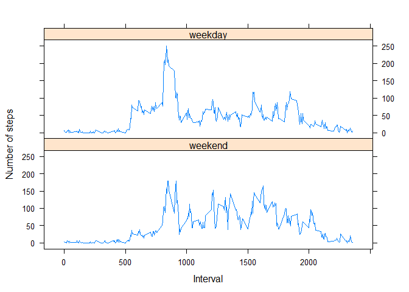

```r
    avgSteps <- aggregate(fitdata4$steps, list(interval = as.numeric(as.character(fitdata4$interval)), weekday = fitdata4$weekday), FUN = "mean")
names(avgSteps)[3] <- "meanOfSteps"
    library(lattice)
    xyplot(avgSteps$meanOfSteps ~ avgSteps$interval | avgSteps$weekday, layout = c(1, 2), type = "l", xlab = "Interval", ylab = "Number of steps")
```